# Introduction to using Maps in R

## NZ Cancer Registry data

### Domicile code data (V3 2013):

http://www.health.govt.nz/nz-health-statistics/data-references/code-tables/common-code-tables/domicile-code-table

### District health board code data:

http://www.health.govt.nz/nz-health-statistics/data-references/code-tables/common-code-tables/district-health-board-code-table

### DHB shapefile

A DHB shapefile is available from:

https://koordinates.com/layer/4324-nz-district-health-boards-2012/

I have downloaded this file (had to create an account), but need to remember that it has a CC attribution license:

- Creative Commons Attribution 3.0 New Zealand
  - You may use this work for commercial purposes.
  - You must attribute the creator in your own works.
- Creator is “Ministry of Health”

```r
## Load the rgeos and rgdal libraries to allow reading and simplifying of the shapefile
library(rgeos)
library(rgdal)

## I don't think that these were used...
## Actually maptools is needs - see below
## library(maptools)
## library(shapefiles)

## Read in the DHB shapefile and count the number of polygons
area <- readOGR(dsn="nz-dhb/",layer="nz-district-health-boards-2012")
sum(unlist(lapply(area@polygons, function(x) nrow(x@Polygons[[1]]@coords))))
```

```
## [1] 240461
```

```r
## DHB info (useful for determining plotting order)
dim(area@data)
```

```
## [1] 20  2
```

```r
head(area@data)
```

```
##   DHB12               NAME
## 0     6              Lakes
## 1    10        Hawke's Bay
## 2     3           Auckland
## 3    18         Canterbury
## 4     2          Waitemata
## 5    16 Nelson Marlborough
```

```r
## Create new object for simplified polygons
areax <- area
## Replace the polygon data with simplified data ("tol" controls amoutn of simplification)
## NB - gSimplify doesn't preserve the area@data slot, so this is a
##      kludge to keep the same object class
## Tolerance of 1000 still gives a very good representation (10,000 starts looking ugly)
tolerance <- 1000
areax@polygons <- gSimplify(area, tol=tolerance, topologyPreserve=TRUE)@polygons
getClass(class(area))
```

```
## Class "SpatialPolygonsDataFrame" [package "sp"]
##
## Slots:
##
## Name:         data    polygons   plotOrder        bbox proj4string
## Class:  data.frame        list     integer      matrix         CRS
##
## Extends:
## Class "SpatialPolygons", directly
## Class "Spatial", by class "SpatialPolygons", distance 2
## Class "SpatialPolygonsNULL", by class "SpatialPolygons", distance 2, with explicit coerce
```

```r
getClass(class(gSimplify(area, tol=tolerance, topologyPreserve=TRUE)))
```

```
## Class "SpatialPolygons" [package "sp"]
##
## Slots:
##
## Name:     polygons   plotOrder        bbox proj4string
## Class:        list     integer      matrix         CRS
##
## Extends: "Spatial", "SpatialPolygonsNULL"
##
## Known Subclasses:
## Class "SpatialPolygonsDataFrame", directly, with explicit coerce
```

```r
## How many polygons do we have now?
sum(unlist(lapply(areax@polygons, function(x) nrow(x@Polygons[[1]]@coords))))
```

```
## [1] 5927
```

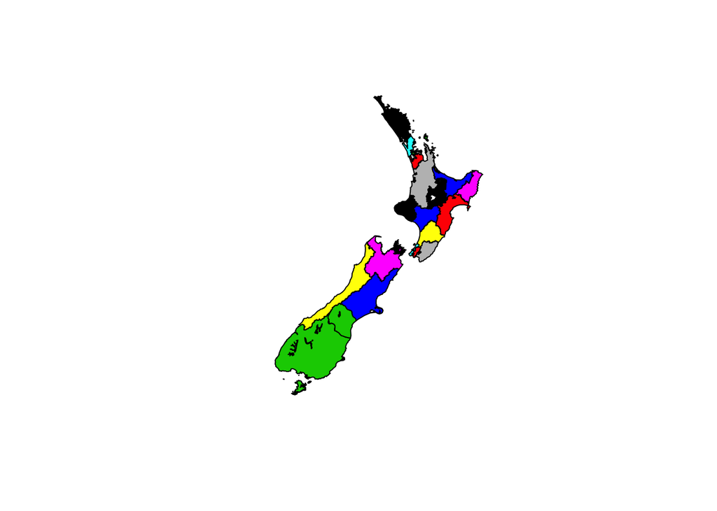

```r
## Base R plot of simplified data (actually looks okay)
plot(areax, col=1:20)
```

We can also use `ggplot` to plot the data, using Hadley’s approach from:

https://github.com/tidyverse/ggplot2/wiki/plotting-polygon-shapefiles

To get this to run in Rmarkdown, I had to modify the instrutcions slightly to replace the `fortify` function with the `tidy` function from the `broom` package (although the code worked fine from the R console - actually this was due to having the `maptools` package loaded, see below). Using `broom` was based on the “future decrepation” message on the `fortify` help page.  
Info about using `tidy` came from:

http://stackoverflow.com/questions/34543468/successor-to-ggplot2fortify

Actually, the solution is simply to load the `maptools` package:

https://github.com/tidyverse/ggplot2/issues/1447

Once this is done, both `ggplot2::fortify` and `broom::tidy`` work just fine.

Plotting takes slightly longer than base R…

```r
library(ggplot2)
library(plyr)
library(maptools)
library(broom)
areax@data$id = rownames(areax@data)
areax.points = tidy(areax, region="id")
areax.df = join(areax.points, areax@data, by="id")
dim(areax.df)
```

```
## [1] 30341     9
```

```r
head(areax.df)
```

```
##      long     lat order  hole piece group id DHB12  NAME
## 1 1897305 5794085     1 FALSE     1   0.1  0     6 Lakes
## 2 1897322 5793783     2 FALSE     1   0.1  0     6 Lakes
## 3 1902270 5793280     3 FALSE     1   0.1  0     6 Lakes
## 4 1903939 5792554     4 FALSE     1   0.1  0     6 Lakes
## 5 1904781 5792174     5 FALSE     1   0.1  0     6 Lakes
## 6 1907514 5792973     6 FALSE     1   0.1  0     6 Lakes
```

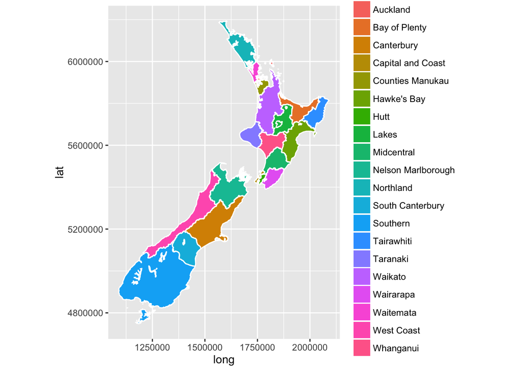

```r
ggplot(areax.df) + aes(long,lat,group=group,fill=NAME) +
  geom_polygon() +
  geom_path(color="white") +
  ## geom_path(color=grey(0.3)) +
  ## geom_path(color="black") +
  coord_equal()
```

Main problem with the plots is that the polygons for Auckland DHB and Capital and Coast DHB are very hard to see because they are so small. Might have to think about merging some of the DHBs together for data display purposes:

- Auckland + Waitemata
- Capital and Coast + Hutt

Actually, just removing the `geom_path` lines improves things a lot (I’ve played around with decreasing the tolerance - it doesn’t improve the plot, and takes vastly longer).

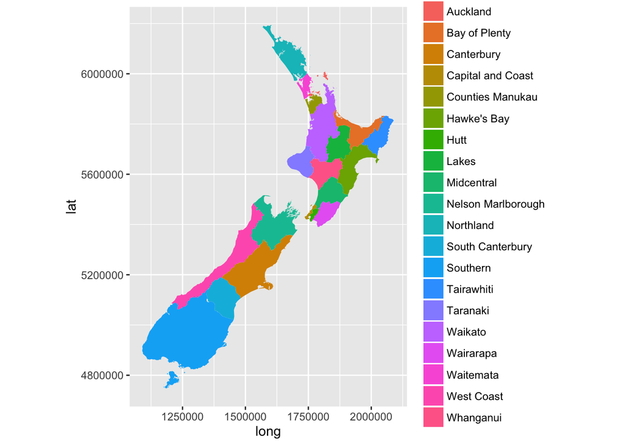

```r
ggplot(areax.df) + aes(long,lat,group=group,fill=NAME) +
  geom_polygon() +
  coord_equal()
```

### Usefull Rbloggers posts

- https://www.r-bloggers.com/r-and-gis-working-with-shapefiles/
- https://www.r-bloggers.com/amateur-mapmaking-getting-started-with-shapefiles/
- Hadley: https://github.com/tidyverse/ggplot2/wiki/plotting-polygon-shapefiles

## Working with general map data

This post:

https://www.r-bloggers.com/things-i-forget-reading-a-shapefile-in-r-with-readogr/

provides a very quick description of what readOGR does - first parameter is directory, second is the shape file being used.

## Installation notes

The R package `rgdal` provides an interface to the `GDAL` software (Geospatial Data Abstraction Library) for working with geospatial data.

I download the current version of GDAL:

```
wget http://download.osgeo.org/gdal/CURRENT/gdal-2.1.2.tar.gz
```

and then compiled from source via the usual:

```
./configure
make
make install
```

which installed it to `/usr/local/bin`.

The `rgdal` package could then be installed in R via:

```r
install.packages(‘rgdal’)
library(rgdal)
```